# car_price_prediction

### Importing Required Packages

```python
import pandas as pd
import numpy as np
import matplotlib.pyplot as plt
import seaborn as sns
pd.options.mode.chained_assignment=None
import plotly.express as px
from sklearn.preprocessing import MinMaxScaler,OrdinalEncoder,OneHotEncoder,StandardScaler
from sklearn.ensemble import RandomForestRegressor
from sklearn.model_selection import train_test_split,GridSearchCV,GroupKFold,KFold
from sklearn.linear_model  import LinearRegression
from sklearn.metrics import mean_absolute_percentage_error as mape ,mean_absolute_error as mae, mean_squared_error
import random
from sklearn.tree import DecisionTreeRegressor
import warnings
warnings.filterwarnings('ignore')
from scipy.stats import zscore,skew
import statsmodels.api as sm
from sklearn.cluster import KMeans
import regex as re
from xgboost import XGBRegressor
import pickle
import plotly.offline as pyo
pyo.init_notebook_mode(connected=True)
from nltk import PorterStemmer
import string
from datetime import datetime
```

### Data Exploration

#### Generice Exploration

```python
data=pd.read_csv('C:/Users/Admin/Desktop/car_detail_en.csv')
```

```python
data.head(2)
```

|  | ad_id | origin | condition | car_model | mileage | exterior_color | interior_color | num_of_doors | seating_capacity | engine | fuel_system | transmission | drive_type | fuel_consumption | describe | brand | grade | year_of_manufacture | car_name | price. price |
| --- | --- | --- | --- | --- | --- | --- | --- | --- | --- | --- | --- | --- | --- | --- | --- | --- | --- | --- | --- | --- |
| 0 | 17042 | Domestic assembly | New car | Truck | 0 Km | White | gray | 2-door | 2-seat | Petrol\t1.0 L | NaN | Manual | RFD - Rear-wheel drive | L/100Km | Super Carry Truck 5-pound mezzanine is equipp... | Suzuki | Super Carry Truck | 2022.0 | Suzuki Super Carry Truck 1.0 MT 2022 | 249 Million |
| 1 | 53794 | Imported | New car | SUV | 0 Km | Black | Black | 5-door | 7-seat | Petrol\t3.4 L | NaN | Automatic | AWD - 4-wheel drive (AWD) | 10\tL/100Km | New Toyota LANDCRUISER 300, imported from Japa... | Toyota | Land Cruiser | 2022.0 | Toyota Land Cruiser 3.5 V6 2022 | 4 Billion 286 Million |

```python
data.columns
```

```
Index(['ad_id', 'origin', 'condition', 'car_model', 'mileage',
       'exterior_color', 'interior_color', 'num_of_doors', 'seating_capacity',
       'engine', 'fuel_system', 'transmission', 'drive_type',
       'fuel_consumption', 'describe', 'brand', 'grade', 'year_of_manufacture',
       'car_name', 'price. price'],
      dtype='object')
```

```python
data.origin.value_counts()
```

```
origin
Domestic assembly    17862
Imported             12790
Name: count, dtype: int64
```

```python
data.condition.value_counts()
```

```
condition
Used car    24582
New car      6070
Name: count, dtype: int64
```

```python
data.car_model.value_counts()
```

```
car_model
SUV                      10646
Sedan                    10268
Hatchback                 2800
Crossover                 2748
Bán tải / Pickup        2384
Van/Minivan               1098
Truck                      425
Coupe                      180
Convertible/Cabriolet       93
Wagon                       10
Name: count, dtype: int64
```

```python
data.mileage.value_counts()
```

```
mileage
0 Km          10442
60,000 Km       720
50,000 Km       695
40,000 Km       619
20,000 Km       616
              ...
50,264 Km         1
16,090 Km         1
101,201 Km        1
21,570 Km         1
96,886 Km         1
Name: count, Length: 1924, dtype: int64
```

```python
data[data.condition=='Used car'].mileage.value_counts()
```

```
mileage
0 Km          4378
60,000 Km      720
50,000 Km      695
40,000 Km      619
20,000 Km      616
              ...
1,995 Km         1
252,000 Km       1
50,264 Km        1
16,090 Km        1
96,886 Km        1
Name: count, Length: 1921, dtype: int64
```

```python
data.exterior_color.value_counts()
```

```
exterior_color
White              9913
Black              6760
Red                3966
Silver             2848
Green              2495
Grey               1016
Brown               835
Yellow              691
Sand                691
Take note           527
Orange              473
Copper              225
Pink                 56
Cream                53
Colorful             46
Different color      25
-                    17
Violet               15
Name: count, dtype: int64
```

```python
data.num_of_doors.value_counts()
```

```
num_of_doors
5-door     16756
4-door     13062
2-door       676
0-door        69
3-door        53
6-door        12
1-door        12
45-door        4
7-door         4
54-door        2
44-door        1
42-door        1
Name: count, dtype: int64
```

```python
data.seating_capacity.value_counts()
```

```
seating_capacity
5-seat     21343
7-seat      5744
8-seat      1761
4-seat       620
2-seat       442
3-seat       333
16-seat      140
6-seat       116
0-seat        55
9-seat        34
10-seat       34
29-seat       12
47-seat        4
15-seat        2
17-seat        2
12-seat        2
30-seat        1
44-seat        1
1-seat         1
11-seat        1
38-seat        1
42-seat        1
20-seat        1
46-seat        1
Name: count, dtype: int64
```

```python
data.engine.value_counts()
```

```
engine
Petrol\t2.0 L    6352
Petrol\t1.5 L    4812
Petrol\t1.6 L    1824
Diesel\t2.2 L    1593
Petrol\t3.0 L    1342
                 ...
Diesel\t6.7 L       1
Diesel\t9.7 L       1
Diesel\t4.0 L       1
Hybrid\t3.3 L       1
Petrol\t0.2 L       1
Name: count, Length: 95, dtype: int64
```

```python
data.fuel_system.value_counts()
```

```
fuel_system
Electronic fuel injection    949
Gasoline                     550
electronic fuel injection    245
Electronic                   218
Direct fuel injection        178
                            ...
private message                1
 2.0 turbo                     1
 Mechanism                     1
V6 3.5                         1
Hybrid                         1
Name: count, Length: 794, dtype: int64
```

```python
data.transmission.value_counts()
```

```
transmission
Automatic    25136
Manual        5499
-               15
Hybrid           2
Name: count, dtype: int64
```

```python
data.drive_type.value_counts()
```

```
drive_type
FWD - Front-wheel drive         16445
RFD - Rear-wheel drive           7176
AWD - 4-wheel drive (AWD)        4514
4WD - Four-wheel drive (4WD)     2402
-                                 107
4WD or AWD                          8
Name: count, dtype: int64
```

```python
data.fuel_consumption.value_counts()
```

```
fuel_consumption
L/100Km        19215
6\tL/100Km      2810
7\tL/100Km      2787
8\tL/100Km      1981
5\tL/100Km      1301
               ...
7.\tL/100Km        1
K0\tL/100Km        1
83\tL/100Km        1
85\tL/100Km        1
6,\tL/100Km        1
Name: count, Length: 76, dtype: int64
```

```python
data['describe'].head()
```

```
0     Super Carry Truck 5-pound mezzanine is equipp...
1    New Toyota LANDCRUISER 300, imported from Japa...
2    **Registration fee support worth 15 million VN...
3     2 interior colors: black, red brown - Car ava...
4    Toyota Innova G 100% new Equipped with 2.0 eng...
Name: describe, dtype: object
```

```python
data.brand.value_counts()
```

```
brand
Toyota           5592
Hyundai          3555
Ford             3370
Mercedes Benz    3191
Kia              2991
                 ...
Hummer              1
Pontiac             1
Scion               1
Dongfeng            1
Changan             1
Name: count, Length: 76, dtype: int64
```

```python
data.grade.value_counts()
```

```
grade
Ranger       1428
Vios         1014
3             838
Morning       792
GLC           784
             ...
Cedric          1
SLK class       1
Express         1
H 100           1
CX20            1
Name: count, Length: 479, dtype: int64
```

```python
data.year_of_manufacture.value_counts().head()
```

```
year_of_manufacture
2023.0    4006
2022.0    3737
2019.0    2914
2021.0    2753
2020.0    2585
Name: count, dtype: int64
```

```python
data.car_name.head()
```

```
0    Suzuki Super Carry Truck 1.0 MT 2022
1         Toyota Land Cruiser 3.5 V6 2022
2         Toyota Innova G 2.0 AT 2023 car
3          Toyota Corolla Cross 1.8G 2023
4         Toyota Innova G 2.0 AT 2022 car
Name: car_name, dtype: object
```

```python
data['price. price'].isnull().any()
```

```
False
```

```python
data.isnull().sum()
```

```
ad_id                      0
origin                     0
condition                  0
car_model                  0
mileage                    0
exterior_color             0
interior_color             0
num_of_doors               0
seating_capacity           0
engine                     0
fuel_system            23910
transmission               0
drive_type                 0
fuel_consumption           0
describe                   0
brand                      0
grade                      0
year_of_manufacture       32
car_name                   0
price. price               0
dtype: int64
```

```python
data.drop(columns='fuel_system',inplace=True)
```

```python
data=data.dropna()
```

```python
data=data.reset_index(drop=True)
```

```python
data.isnull().any().sum()
```

```
0
```

```python
data.columns
```

```
Index(['ad_id', 'origin', 'condition', 'car_model', 'mileage',
       'exterior_color', 'interior_color', 'num_of_doors', 'seating_capacity',
       'engine', 'transmission', 'drive_type', 'fuel_consumption', 'describe',
       'brand', 'grade', 'year_of_manufacture', 'car_name', 'price. price'],
      dtype='object')
```

```python
data.groupby('condition').mileage.value_counts().nlargest(2)
```

```
condition  mileage
New car    0 Km       6064
Used car   0 Km       4364
Name: count, dtype: int64
```

```python
data.dtypes
```

```
ad_id                    int64
origin                  object
condition               object
car_model               object
mileage                 object
exterior_color          object
interior_color          object
num_of_doors            object
seating_capacity        object
engine                  object
transmission            object
drive_type              object
fuel_consumption        object
describe                object
brand                   object
grade                   object
year_of_manufacture    float64
car_name                object
price. price            object
dtype: object
```

#### Changing Mileage Values

```python
data.mileage=data.mileage.str.split(' ').apply(lambda x : x[0])
```

```python
data.mileage=data.mileage.str.replace(',','')
```

```python
data.mileage=data.mileage.astype('int64')
```

```python
data.rename(columns={'price. price':'price'},inplace=True)
```

```python
data.head(3)
```

|  | ad_id | origin | condition | car_model | mileage | exterior_color | interior_color | num_of_doors | seating_capacity | engine | transmission | drive_type | fuel_consumption | describe | brand | grade | year_of_manufacture | car_name | price |
| --- | --- | --- | --- | --- | --- | --- | --- | --- | --- | --- | --- | --- | --- | --- | --- | --- | --- | --- | --- |
| 0 | 17042 | Domestic assembly | New car | Truck | 0 | White | gray | 2-door | 2-seat | Petrol\t1.0 L | Manual | RFD - Rear-wheel drive | L/100Km | Super Carry Truck 5-pound mezzanine is equipp... | Suzuki | Super Carry Truck | 2022.0 | Suzuki Super Carry Truck 1.0 MT 2022 | 249 Million |
| 1 | 53794 | Imported | New car | SUV | 0 | Black | Black | 5-door | 7-seat | Petrol\t3.4 L | Automatic | AWD - 4-wheel drive (AWD) | 10\tL/100Km | New Toyota LANDCRUISER 300, imported from Japa... | Toyota | Land Cruiser | 2022.0 | Toyota Land Cruiser 3.5 V6 2022 | 4 Billion 286 Million |
| 2 | 73954 | Domestic assembly | New car | Crossover | 0 | Silver | Brown | 5-door | 8-seat | Petrol\t2.0 L | Automatic | RFD - Rear-wheel drive | L/100Km | **Registration fee support worth 15 million VN... | Toyota | Innova | 2023.0 | Toyota Innova G 2.0 AT 2023 car | 885 Million |

```python
us_dollar_exchange=0.000042
```

```python
# ----------- price formats in price column --------------
''' 1 Billion
    Billion 456 Million
    345 Million
    1 Billion 768 million '''
```

```
' 1 Billion\n    Billion 456 Million\n    345 Million\n    1 Billion 768 million '
```

#### Extracting Price values

```python
data.price=data.price.str.lower()
```

First resolving wrong format Billion {int} million

```python
zero_index=data[data.price.str.strip(' ').apply(lambda x : not x[0].isdigit())].index.to_list()
```

```python
zero_values=data.iloc[zero_index].price.apply(lambda x : '1 '+x).to_list()
```

```python
car_data=data.copy()
```

```python
car_data.head(2)
```

|  | ad_id | origin | condition | car_model | mileage | exterior_color | interior_color | num_of_doors | seating_capacity | engine | transmission | drive_type | fuel_consumption | describe | brand | grade | year_of_manufacture | car_name | price |
| --- | --- | --- | --- | --- | --- | --- | --- | --- | --- | --- | --- | --- | --- | --- | --- | --- | --- | --- | --- |
| 0 | 17042 | Domestic assembly | New car | Truck | 0 | White | gray | 2-door | 2-seat | Petrol\t1.0 L | Manual | RFD - Rear-wheel drive | L/100Km | Super Carry Truck 5-pound mezzanine is equipp... | Suzuki | Super Carry Truck | 2022.0 | Suzuki Super Carry Truck 1.0 MT 2022 | 249 million |
| 1 | 53794 | Imported | New car | SUV | 0 | Black | Black | 5-door | 7-seat | Petrol\t3.4 L | Automatic | AWD - 4-wheel drive (AWD) | 10\tL/100Km | New Toyota LANDCRUISER 300, imported from Japa... | Toyota | Land Cruiser | 2022.0 | Toyota Land Cruiser 3.5 V6 2022 | 4 billion 286 million |

```python
car_data['changed_price']=car_data['price']
```

```python
car_data.loc[zero_index,'changed_price']=zero_values
```

```python
car_data.iloc[zero_index][['price','changed_price']].tail(5)
```

|  | price | changed_price |
| --- | --- | --- |
| 30350 | billion 519 million | 1 billion 519 million |
| 30446 | billion 286 million | 1 billion 286 million |
| 30499 | billion 286 million | 1 billion 286 million |
| 30600 | billion 325 million | 1 billion 325 million |
| 30605 | billion 286 million | 1 billion 286 million |

converting format of only billion values to {} billion 0 million for making every value of same format

```python
car_data.price=car_data.price.str.lower().str.strip(' ')
```

```python
only_billion_index=car_data[~(car_data.price.str.contains('million'))].index.to_list()
```

```python
only_billion_values=car_data.iloc[only_billion_index]['price'].apply(lambda x : x+' 0 million').to_list()
```

```python
car_data.loc[only_billion_index,'changed_price']=only_billion_values
```

```python
car_data.iloc[only_billion_index][['price','changed_price']].tail(5)
```

|  | price | changed_price |
| --- | --- | --- |
| 27593 | 1 billion | 1 billion 0 million |
| 27652 | 2 billion | 2 billion 0 million |
| 29581 | 2 billion | 2 billion 0 million |
| 29995 | 2 billion | 2 billion 0 million |
| 30501 | 1 billion | 1 billion 0 million |

Using eval method to covert text to numbers by replacing million with 1e6 and billion with 1e9

```python
car_data['car_price']=\
car_data.changed_price.str.replace(r'billion|billions','*1e9 +',regex=True)\
.str.replace('million|millions','*1e6',regex=True).\
str.strip('s').\
apply(lambda x : eval(x))
```

```python
car_data.car_price.describe()
```

```
count    3.062000e+04
mean     1.174406e+09
std      2.061059e+09
min      1.800000e+07
25%      4.100000e+08
50%      6.200000e+08
75%      1.030000e+09
max      5.400000e+10
Name: car_price, dtype: float64
```

```python
car_data['price_dollars']=car_data.car_price*us_dollar_exchange
```

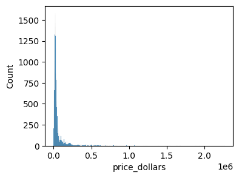

```python
plt.figure(figsize=(4,3))
sns.histplot(car_data.price_dollars)
```

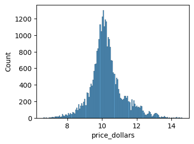

```python
plt.figure(figsize=(4,3))
sns.histplot(np.log(car_data.price_dollars))
```

```python
car_data.dtypes
```

```
ad_id                    int64
origin                  object
condition               object
car_model               object
mileage                  int64
exterior_color          object
interior_color          object
num_of_doors            object
seating_capacity        object
engine                  object
transmission            object
drive_type              object
fuel_consumption        object
describe                object
brand                   object
grade                   object
year_of_manufacture    float64
car_name                object
price                   object
changed_price           object
car_price              float64
price_dollars          float64
dtype: object
```

```python
car_data.num_of_doors=car_data.num_of_doors.str.split('-').apply(lambda x : int(x[0]))
```

```python
car_data.num_of_doors.unique()
```

```
array([ 2,  5,  4,  6,  1,  3, 45, 44,  7, 54,  0, 42], dtype=int64)
```

```python
car_data.seating_capacity.unique()
```

```
array(['2-seat', '7-seat', '8-seat', '5-seat', '3-seat', '4-seat',
       '6-seat', '16-seat', '20-seat', '47-seat', '10-seat', '29-seat',
       '11-seat', '9-seat', '42-seat', '15-seat', '17-seat', '12-seat',
       '38-seat', '30-seat', '1-seat', '44-seat', '0-seat', '46-seat'],
      dtype=object)
```

```python
car_data.seating_capacity=car_data.seating_capacity.str.split('-').apply(lambda x : int(x[0]))
```

```python
car_data.seating_capacity.unique()
```

```
array([ 2,  7,  8,  5,  3,  4,  6, 16, 20, 47, 10, 29, 11,  9, 42, 15, 17,
       12, 38, 30,  1, 44,  0, 46], dtype=int64)
```

```python
car_data.columns
```

```
Index(['ad_id', 'origin', 'condition', 'car_model', 'mileage',
       'exterior_color', 'interior_color', 'num_of_doors', 'seating_capacity',
       'engine', 'transmission', 'drive_type', 'fuel_consumption', 'describe',
       'brand', 'grade', 'year_of_manufacture', 'car_name', 'price',
       'changed_price', 'car_price', 'price_dollars'],
      dtype='object')
```

```python
car_data.price_dollars=car_data.price_dollars.astype('int64')
```

```python
car_data.engine.head(2)
```

```
0    Petrol\t1.0 L
1    Petrol\t3.4 L
Name: engine, dtype: object
```

#### converting engine values to readable and different columns

```python
# first stripping trailing L and spaces later splitting by \t to get engine capacity and engine type
engine=pd.DataFrame(car_data.engine.str.strip('L| ').str.split('\t').to_list(),
            columns=['engine_type','engine_capacity'])
```

```python
car_data[['engine_type','engine_capacity']]=engine[['engine_type','engine_capacity']]
```

```python
car_data.engine_capacity=car_data.engine_capacity.astype('float64')
```

```python
car_data[['engine','engine_capacity','engine_type']].head(3)
```

|  | engine | engine_capacity | engine_type |
| --- | --- | --- | --- |
| 0 | Petrol\t1.0 L | 1.0 | Petrol |
| 1 | Petrol\t3.4 L | 3.4 | Petrol |
| 2 | Petrol\t2.0 L | 2.0 | Petrol |

```python
## thinking of filling engine_capaacity with ml
```

```python
car_data.origin.unique()
```

```
array(['Domestic assembly', 'Imported'], dtype=object)
```

```python
car_data.condition.unique()
```

```
array(['New car', 'Used car'], dtype=object)
```

```python
car_data.car_model.unique()
```

```
array(['Truck', 'SUV', 'Crossover', 'Van/Minivan', 'Bán tải / Pickup',
       'Sedan', 'Hatchback', 'Wagon', 'Coupe', 'Convertible/Cabriolet'],
      dtype=object)
```

```python
car_data.mileage=car_data.mileage.astype('int64')
```

```python
car_data.exterior_color.unique()
```

```
array(['White', 'Black', 'Silver', 'Copper', 'Grey', 'Red', 'Brown',
       'Green', 'Take note', 'Orange', 'Yellow', 'Sand', 'Colorful',
       'Cream', 'Different color', 'Pink', 'Violet', '-'], dtype=object)
```

```python
index_color=car_data[car_data.exterior_color=='-'].index.to_list()
```

```python
car_data.loc[index_color,'exterior_color']='Take note'
```

```python
car_data.exterior_color.unique()
```

```
array(['White', 'Black', 'Silver', 'Copper', 'Grey', 'Red', 'Brown',
       'Green', 'Take note', 'Orange', 'Yellow', 'Sand', 'Colorful',
       'Cream', 'Different color', 'Pink', 'Violet'], dtype=object)
```

```python
car_data.interior_color.unique()
```

```
array(['gray', 'Black', 'Brown', 'Cream', 'Yellow', 'Colorful', 'Sand',
       'Grey', 'Red', 'Silver', 'Green', '-', 'Different color', 'White',
       'Orange', 'Copper', 'Pink', 'Violet'], dtype=object)
```

```python
index_int=car_data[car_data.interior_color=='-'].index.to_list()
```

```python
car_data.loc[index_int,'interior_color']='Different color'
```

```python
car_data.interior_color.unique()
```

```
array(['gray', 'Black', 'Brown', 'Cream', 'Yellow', 'Colorful', 'Sand',
       'Grey', 'Red', 'Silver', 'Green', 'Different color', 'White',
       'Orange', 'Copper', 'Pink', 'Violet'], dtype=object)
```

```python
car_data.transmission.unique()
```

```
array(['Manual', 'Automatic', '-', 'Hybrid'], dtype=object)
```

```python
index_tra=car_data[car_data.transmission=='-'].index.to_list()
```

```python
car_data.loc[index_tra,'transmission']='Hybrid'
```

```python
car_data.transmission.unique()
```

```
array(['Manual', 'Automatic', 'Hybrid'], dtype=object)
```

```python
car_data.columns
```

```
Index(['ad_id', 'origin', 'condition', 'car_model', 'mileage',
       'exterior_color', 'interior_color', 'num_of_doors', 'seating_capacity',
       'engine', 'transmission', 'drive_type', 'fuel_consumption', 'describe',
       'brand', 'grade', 'year_of_manufacture', 'car_name', 'price',
       'changed_price', 'car_price', 'price_dollars', 'engine_type',
       'engine_capacity'],
      dtype='object')
```

#### Filling drive_type missing values

```python
car_data.drive_type.unique()
```

```
array(['RFD - Rear-wheel drive', 'AWD - 4-wheel drive (AWD)',
       'FWD - Front-wheel drive', '4WD - Four-wheel drive (4WD)',
       '4WD or AWD', '-'], dtype=object)
```

```python
(car_data.drive_type=='-').sum()
```

```
107
```

1.creating a lookup containing mode of drive_type grouped by grade and brand [named 'f' for convinience] 2.Making sure only one value is present in mode and not any [index_f and values_f is used to change values from multiple to single by removing other values from nparray] 3.changing values in data_frame to extracted lookup values [index_drive and values_drive are index and values for values to be changed in df]

```python
f=car_data.groupby(['brand','grade']).drive_type.agg(pd.Series.mode).reset_index()
```

```python
index_f=f[f.drive_type.apply(lambda x : type(x))==np.ndarray].index.to_list()
```

```python
values_f=f[f.drive_type.apply(lambda x : type(x))==np.ndarray].drive_type.apply(lambda x : x[0])
```

```python
f.loc[index_f,'drive_type']=list(values_f)
```

```python
index_drive=car_data[car_data.drive_type=='-'].index
```

```python
values_drive=list(car_data[car_data.drive_type=='-'].\
merge(f,on=['brand','grade'],how='left').drive_type_y)
```

# creating a copy of original df before changing to retain data if wrong cells are changed or wrong values are entered -- 1st copy of car_data

```python
car_data_1=car_data.copy()
```

```python
car_data_1.loc[index_drive,'drive_type']=values_drive
```

```python
car_data_1.drive_type.unique()
```

```
array(['RFD - Rear-wheel drive', 'AWD - 4-wheel drive (AWD)',
       'FWD - Front-wheel drive', '4WD - Four-wheel drive (4WD)',
       '4WD or AWD', '-'], dtype=object)
```

```python
car_data_1.drop(car_data_1[car_data_1.drive_type=='-'].index.to_list(),inplace=True)
```

```python
car_data_1=car_data_1.reset_index(drop=True)
```

```python
car_data_1.fuel_consumption.head(3)
```

```
0        L/100Km
1    10\tL/100Km
2        L/100Km
Name: fuel_consumption, dtype: object
```

#### changing fuel_consumption values

```python
values=car_data_1.fuel_consumption.str.lower().str.replace('\t','')
```

extracting values fuel_consumption to make it a int column which would contain fuel_usage per 100km

```python
# stripping off L/100km as it is commoon for every value. replacing trailing characters to only extract values
values=values.str.replace('l/100km','').str.replace(r'l|k|,','',regex=True)
```

```python
values.loc[values[values==''].index.to_list()]=0
```

```python
values=values.astype('float64')
```

```python
car_data_1['fuel_per_100km']=values
```

Too many nulls and outliers in the fuel_per_100km data to change it performed the following 1.creating a lookup table for values of fuel for each car_model. [car model is selected because extracting by car type and grade would not work as there are many nulls] [also model would give almost an accurate assumption of average fuel consumption] 2.only considering values which are not outliers and nulls for lookup 3.extracting index and values to change the original df [index_fuel,values_fuel]

```python
fuel_fillup=car_data_1[~(car_data_1.fuel_per_100km==0)&(car_data_1.fuel_per_100km<70)].\
groupby('car_model').fuel_per_100km.mean().round(2).reset_index()
```

```python
index_fuel=car_data_1[car_data_1.fuel_per_100km==0].index
```

```python
values_fuel=list(car_data_1[car_data_1.fuel_per_100km==0].\
merge(fuel_fillup,on='car_model',how='left').fuel_per_100km_y)
```

-- creating another copy as check point 2nd copy of car_data

```python
car_data_2=car_data_1.copy()
```

```python
car_data_2.loc[index_fuel,'fuel_per_100km']=values_fuel
```

```python
car_data_2.fuel_per_100km.unique()
```

```
array([9.310e+00, 1.000e+01, 7.030e+00, 8.020e+00, 7.000e+00, 9.000e+00,
       6.000e+00, 5.720e+00, 8.000e+00, 6.980e+00, 5.000e+00, 1.500e+01,
       1.600e+01, 4.000e+00, 1.200e+01, 5.750e+00, 1.100e+01, 7.360e+00,
       7.710e+00, 9.170e+00, 2.000e+00, 2.000e+01, 1.300e+01, 8.490e+00,
       1.400e+01, 6.500e+01, 6.600e+01, 1.700e+01, 4.200e+01, 1.800e+01,
       3.000e+00, 1.000e+00, 5.650e+02, 6.800e+01, 7.500e+00, 1.000e+02,
       7.700e+01, 7.700e+00, 5.500e+01, 4.000e+01, 1.000e+04, 5.920e+02,
       8.500e+00, 8.900e+01, 8.300e+01, 8.500e+01, 6.500e+03, 7.500e+01,
       5.500e+00, 9.800e+01, 8.700e+00, 5.800e+00, 1.000e+05, 2.250e+02,
       5.700e+00, 7.800e+00, 6.800e+00, 4.288e+03, 6.500e+00, 1.110e+02,
       2.000e+05, 5.800e+01, 4.500e+01])
```

```python
car_data_2.loc[car_data_2[car_data_2.engine_type=='-'].index.to_list(),'engine_type']='Petrol'
```

```python
car_data_2.engine_type.unique()
```

```
array(['Petrol', 'Diesel', 'Hybrid', 'Electric'], dtype=object)
```

```python
car_data_2['year_of_manufactue']=pd.to_datetime(car_data.year_of_manufacture,format='%Y').dt.year
```

```python
car_data_2.year_of_manufacture.unique()
```

```
array([2022., 2023., 2017., 2021., 2009., 2016., 2006., 2013., 2019.,
       2008., 2011., 2020., 2015., 2018., 2010., 2005., 2014., 2012.,
       2007., 1990., 1999., 2004., 2000., 2002., 2003., 1997., 1994.,
       1991., 1995., 2001., 1993., 1992., 1998., 1996.])
```

```python
car_data_2.price_dollars.isnull().any()
```

```
False
```

```python
car_data_2['price_dollars'].describe()
```

```
count    3.061800e+04
mean     4.932679e+04
std      8.656700e+04
min      7.560000e+02
25%      1.722000e+04
50%      2.604000e+04
75%      4.326000e+04
max      2.268000e+06
Name: price_dollars, dtype: float64
```

```python
car_data_2.dtypes
```

```
ad_id                    int64
origin                  object
condition               object
car_model               object
mileage                  int64
exterior_color          object
interior_color          object
num_of_doors             int64
seating_capacity         int64
engine                  object
transmission            object
drive_type              object
fuel_consumption        object
describe                object
brand                   object
grade                   object
year_of_manufacture    float64
car_name                object
price                   object
changed_price           object
car_price              float64
price_dollars            int64
engine_type             object
engine_capacity        float64
fuel_per_100km         float64
year_of_manufactue       int32
dtype: object
```

```python
car_data_2.isnull().any().sum()
```

```
1
```

### EDA

```python
eda_data=car_data_2.copy()
```

```python
color=sns.color_palette()
```

```python
eda_data['price_log']=np.log(eda_data.price_dollars)
```

```python
eda_data.select_dtypes(include=['int64','float64']).columns
```

```
Index(['ad_id', 'mileage', 'num_of_doors', 'seating_capacity',
       'year_of_manufacture', 'car_price', 'price_dollars', 'engine_capacity',
       'fuel_per_100km', 'price_log'],
      dtype='object')
```

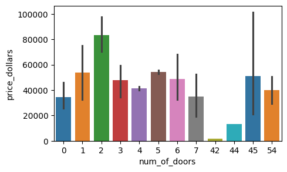

```python
plt.figure(figsize=(5,3))
sns.barplot(x='num_of_doors',y='price_dollars',data=eda_data,palette=color)
```

## seems no correlation have to investigate [probably remove zero doors too]

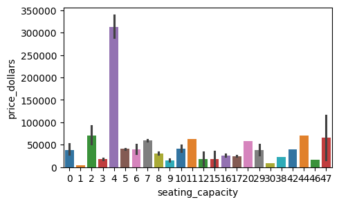

```python
plt.figure(figsize=(5,3))
sns.barplot(x='seating_capacity',y='price_dollars',data=eda_data,palette=color)
```

# 4 seater seems pretty uncommon have to look [0 seats should be removed or investigated] doesnt seem to have correlation

```python
eda_data['year_of_manufacture']=eda_data.year_of_manufacture.astype('int64')
```

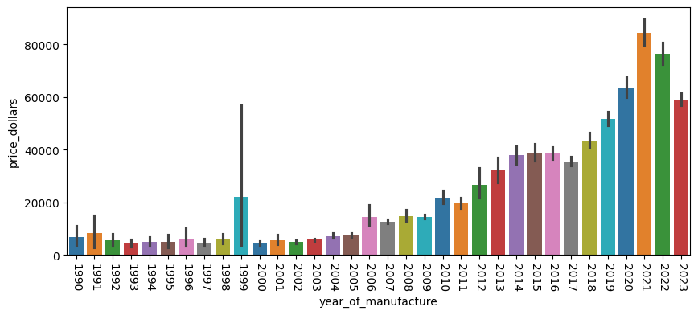

```python
plt.figure(figsize=(10,4))
plot=sns.barplot(x='year_of_manufacture',y='price_dollars',data=eda_data,palette=color)
plot.tick_params(axis='x',rotation=270)
plt.show()
```

# 1999 cars seems to have outliers should be checked car company has caused the increase or decrease in the values. seems to have some correlation'engine_capacity','fuel_per_100km', 'year_of_manufactue'

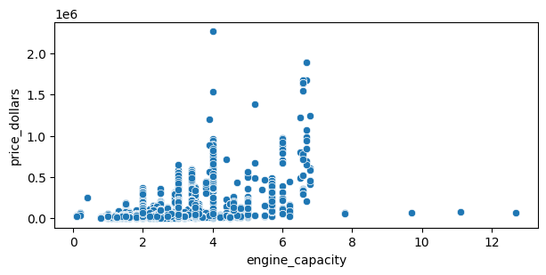

```python
plt.figure(figsize=(7,3))
sns.scatterplot(x='engine_capacity',y='price_dollars',data=eda_data)
```

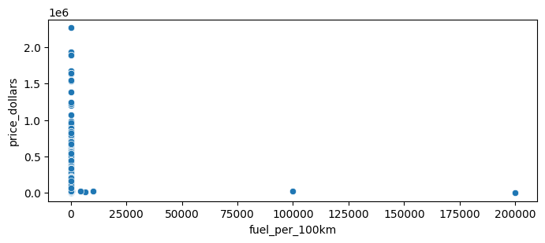

```python
plt.figure(figsize=(8,3))
sns.scatterplot(x='fuel_per_100km',y='price_dollars',data=eda_data)
```

would have to remove outliers by zscore

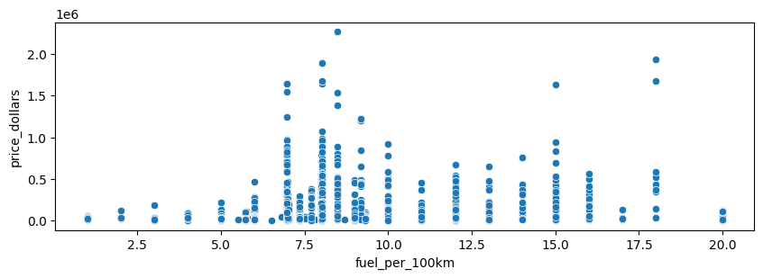

```python
plt.figure(figsize=(10,3))
sns.scatterplot(x='fuel_per_100km',y='price_dollars',data=eda_data[eda_data.fuel_per_100km<40],)
```

doesnt seem to have correlation

```python
eda_data.select_dtypes(include='object').columns
```

```
Index(['origin', 'condition', 'car_model', 'exterior_color', 'interior_color',
       'engine', 'transmission', 'drive_type', 'fuel_consumption', 'describe',
       'brand', 'grade', 'car_name', 'price', 'changed_price', 'engine_type'],
      dtype='object')
```

'origin', 'condition', 'car_model', 'exterior_color', 'interior_color', 'engine', 'transmission', 'drive_type', 'fuel_consumption', 'describe', 'brand', 'grade', 'car_name', 'price', 'changed_price', 'engine_type'

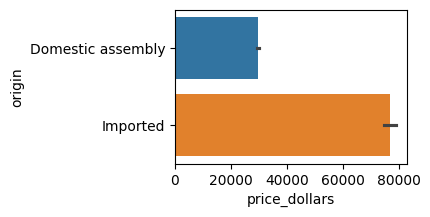

```python
plt.figure(figsize=(3,2))
sns.barplot(x='price_dollars',y='origin',data=eda_data,palette=sns.color_palette())
```

imported cars seems to have high prices than domestic assembly.

```python
px.box(y='condition',x='price_dollars',data_frame=eda_data)
```

[interactive chart not shown]

New car seems to have higher prices than used cars which is pretty much obvious

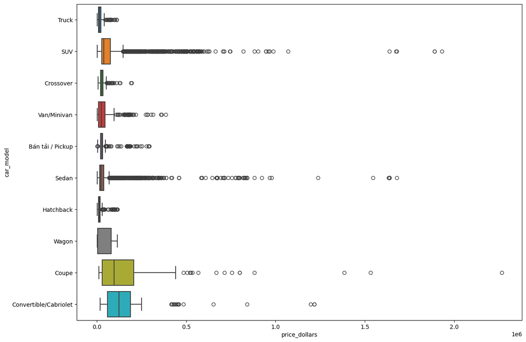

```python
plt.figure(figsize=(14,10))
fig=sns.boxplot(y='car_model',x='price_dollars',data=eda_data,palette=color,linewidth=1.4)
plt.show()
```

'exterior_color', 'interior_color', 'engine', 'transmission', 'drive_type', 'fuel_consumption', 'describe', 'brand', 'grade', 'car_name', 'price', 'changed_price', 'engine_type'

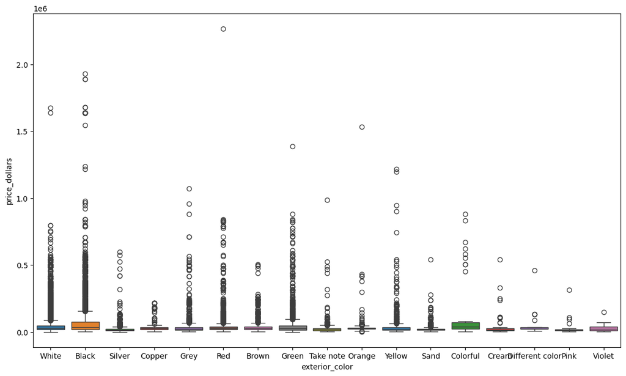

```python
plt.figure(figsize=(14,8))
fig=sns.boxplot(x='exterior_color',y='price_dollars',data=eda_data,palette=color)
plt.show()
```

Black,colorful seems to have max mean value among colors others pretty much even

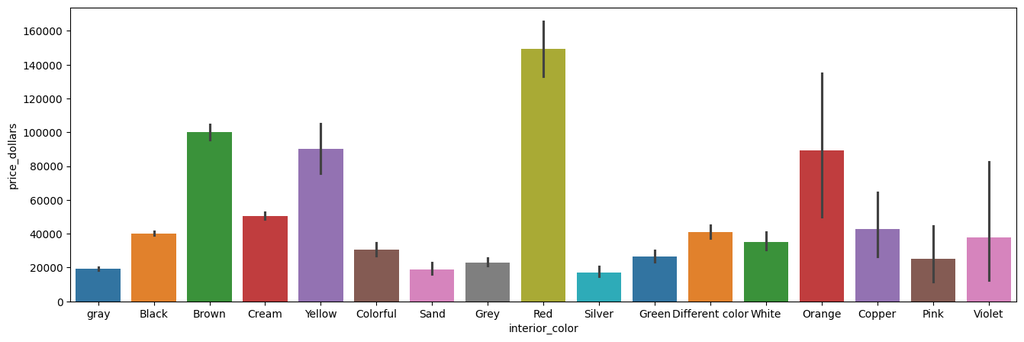

```python
plt.figure(figsize=(16,5))
fig=sns.barplot(x='interior_color',y='price_dollars',data=eda_data,palette=color)
plt.show()
```

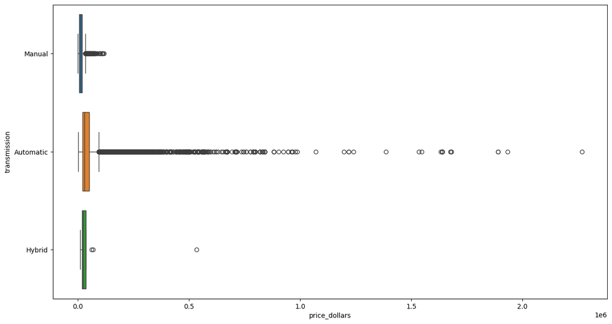

```python
plt.figure(figsize=(15,8))
fig=sns.boxplot(y='transmission',x='price_dollars',data=eda_data,palette=color)
plt.show()
```

- Automatic has high prices where manual and hybrid seems pretty even - seems to have good coorelation with price 'drive_type', 'fuel_consumption', 'describe', 'brand', 'grade', 'car_name', 'price', 'changed_price', 'engine_type'

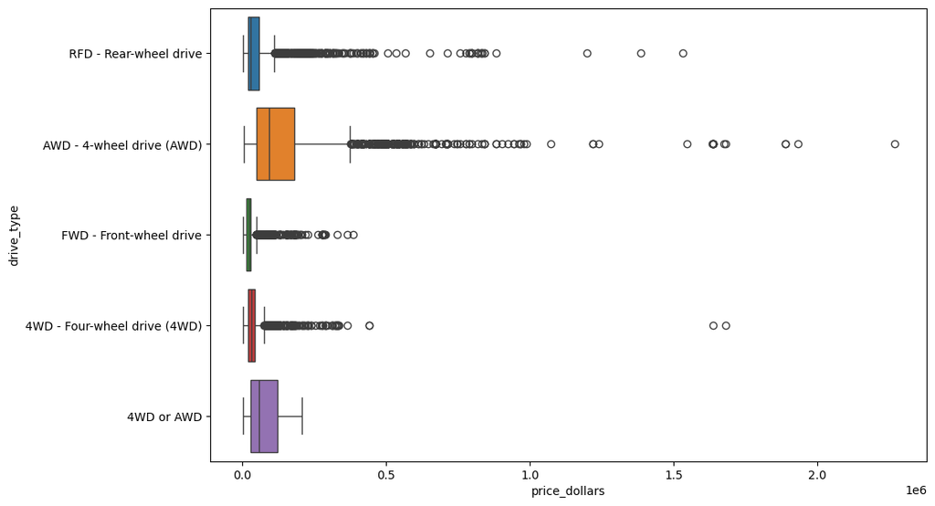

```python
plt.figure(figsize=(11,7))
fig=sns.boxplot(y='drive_type',x='price_dollars',data=eda_data,palette=color)
plt.show()
```

AWD and 4wd-awd had more average price most probably because they are used in large vehicles like truck whereas other types seems pretty even - correlation expected

```python
fig=px.box(x='grade',y='price_dollars',animation_frame='brand',data_frame=eda_data,range_y=[0,1.3e5])
```

```python
# slowing down the animation for clearer look
fig.layout.updatemenus[0].buttons[0].args[1]['frame']['duration'] = 1000
fig.layout.updatemenus[0].buttons[0].args[1]['transition']['duration'] = 0.001
```

```python
fig.show()
```

[interactive chart not shown]

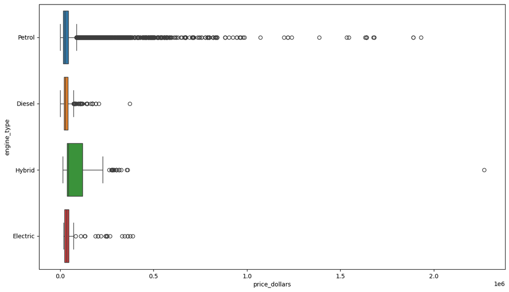

```python
plt.figure(figsize=(14,8))
fig=sns.boxplot(y='engine_type',x='price_dollars',data=eda_data,palette=sns.color_palette())
plt.show()
```

Hybrid had higher avergae prices,electric and diesel seems to have low prices

```python
plot_data=eda_data.groupby(['brand','car_model']).price_dollars.mean().reset_index()
```

```python
px.bar(x='car_model',y='price_dollars',animation_frame='brand',data_frame=plot_data)
```

[interactive chart not shown]

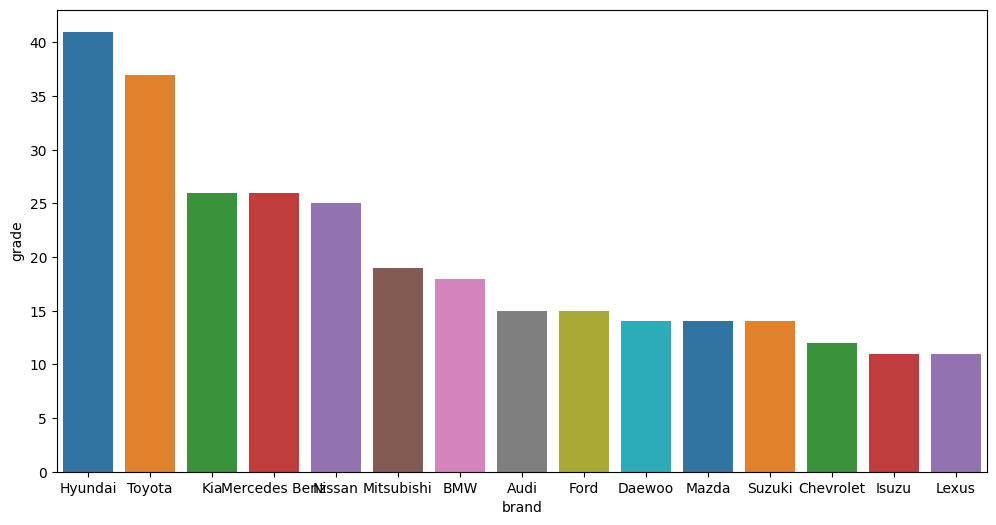

```python
plt.figure(figsize=(12,6))
sns.barplot(data=eda_data.groupby('brand').grade.nunique().reset_index().nlargest(15,'grade'),
            x='brand',y='grade',palette=color)
```

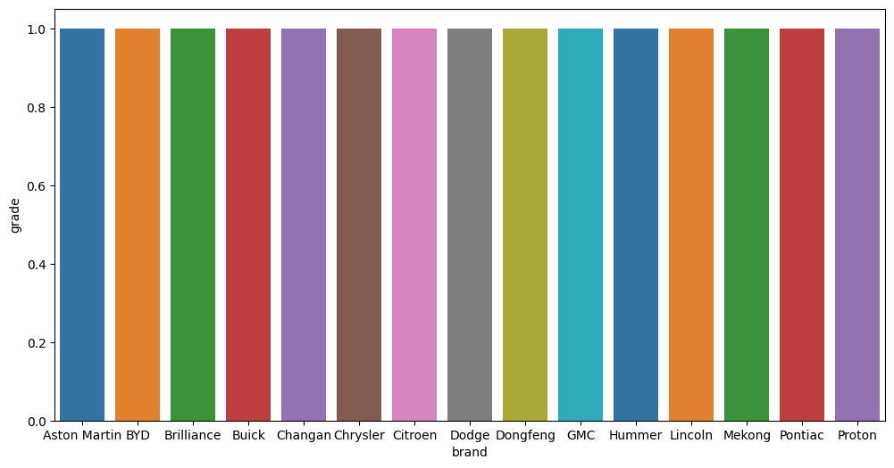

```python
plt.figure(figsize=(12,6))
sns.barplot(data=eda_data.groupby('brand').grade.nunique().reset_index().nsmallest(15,'grade'),
            x='brand',y='grade',palette=color)
```

### EDA [with logged price values]

```python
eda_data.select_dtypes(include=['int64','float64']).columns
```

```
Index(['ad_id', 'mileage', 'num_of_doors', 'seating_capacity',
       'year_of_manufacture', 'car_price', 'price_dollars', 'engine_capacity',
       'fuel_per_100km', 'price_log'],
      dtype='object')
```

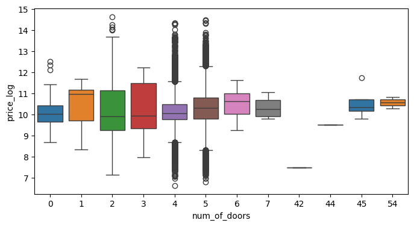

```python
plt.figure(figsize=(8,4))
sns.boxplot(x='num_of_doors',y='price_log',data=eda_data,palette=color)
```

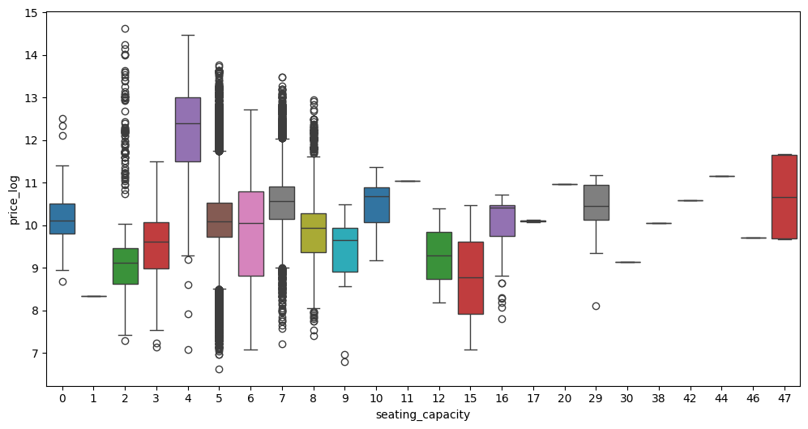

```python
plt.figure(figsize=(12,6))
sns.boxplot(x='seating_capacity',y='price_log',data=eda_data,palette=color)
```

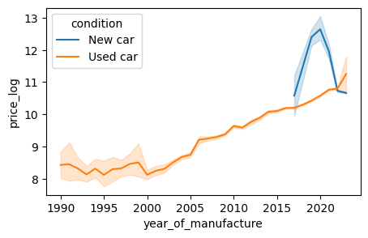

```python
plt.figure(figsize=(5,3))
sns.lineplot(x='year_of_manufacture',y='price_log',data=eda_data,hue='condition')
```

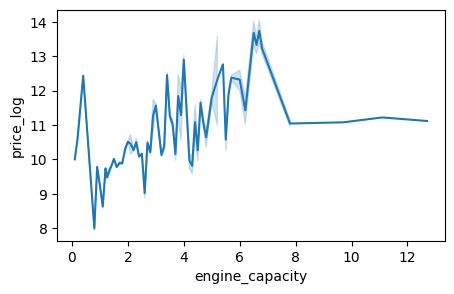

```python
plt.figure(figsize=(5,3))
sns.lineplot(x='engine_capacity',y='price_log',data=eda_data)
```

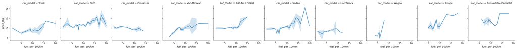

```python
grid=sns.FacetGrid(eda_data[eda_data.fuel_per_100km<40],col='car_model')
grid.map(sns.lineplot,'fuel_per_100km','price_log')
```

['origin', 'condition', 'car_model', 'exterior_color', 'interior_color', 'engine', 'transmission', 'drive_type', 'fuel_consumption', 'describe', 'brand', 'grade', 'car_name', 'price', 'changed_price', 'engine_type'],

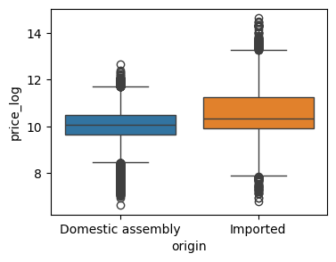

```python
plt.figure(figsize=(4,3))
sns.boxplot(x='origin',y='price_log',data=eda_data,palette=color)
```

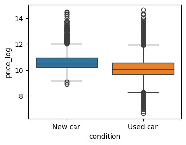

```python
plt.figure(figsize=(4,3))
sns.boxplot(x='condition',y='price_log',data=eda_data,palette=color)
```

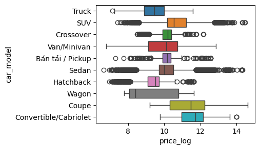

```python
plt.figure(figsize=(4,3))
sns.boxplot(y='car_model',x='price_log',data=eda_data,palette=color)
```

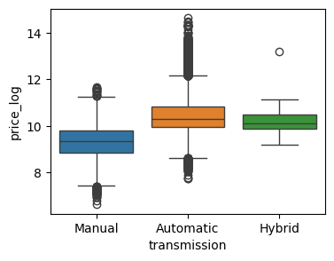

```python
plt.figure(figsize=(4,3))
sns.boxplot(x='transmission',y='price_log',data=eda_data,palette=color)
```

### Finding and Removing Outliers and Cleaning Data

#### Finding and removing brand and grade values which are in very less quantity and would not be very useful in predicting prices

- 1st copy of eda_data

```python
req_data=eda_data.copy()
```

```python
req_data.shape[0]
```

```
30618
```

```python
req_data['brand_grade']=req_data.brand+'_'+req_data.grade
```

```python
req_data['extracted_name']=req_data.car_name.str.replace('car|Car','').\
apply(lambda x : re.split(re.compile(r'\b\d{4}\b'),x)[0]).\
apply(lambda x : re.sub(re.compile(r'\d+\.\d+'),'',x)).str.strip(' ')
```

```python
req_data.extracted_name
```

```
0         Suzuki Super Carry Truck  MT
1              Toyota Land Cruiser  V6
2                  Toyota Innova G  AT
3               Toyota Corolla Cross G
4                  Toyota Innova G  AT
                     ...
30613                Nissan X trail AT
30614                     Lexus ES 250
30615    Ford Ranger Wildtrack  4x4 AT
30616            Mercedes Benz GLC 200
30617     Audi Q8 55 TFSI S-Line Quatt
Name: extracted_name, Length: 30618, dtype: object
```

```python
table=(req_data.brand_grade.value_counts()*100/req_data.shape[0]).reset_index()
```

```python
filter_list=table[~(table['count']<0.03)]['brand_grade'].to_list()
```

```python
filter_index=req_data[~(req_data.brand_grade.isin(filter_list))].index.tolist()
```

```python
data_1=req_data.copy()
```

```python
data_1.loc[filter_index,'grade']='other'
```

```python
data_1.shape[0]-req_data.shape[0]
```

```
0
```

```python
data_1['brand_grade']=data_1.brand+'_'+data_1.grade
```

```python
table=(data_1.brand_grade.value_counts()*100/data_1.shape[0]).reset_index()
```

```python
filter_list=table[~(table['count']<0.03)]['brand_grade'].to_list()
```

```python
data_1=data_1[data_1.brand_grade.isin(filter_list)]
```

```python
data_1.shape[0]-req_data.shape[0]
```

```
-193
```

#### exploring for more outliers

- checking by car_model first for num_of_doors and seating_capacity outliers and may be change it
- starting with num_of_doors

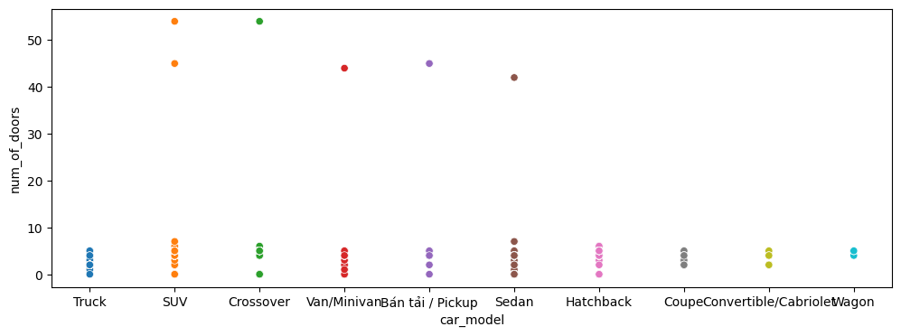

```python
plt.figure(figsize=(12,4))
sns.scatterplot(x='car_model',y='num_of_doors',data=data_1,hue='car_model',legend=False)
```

exploring outliers of this form

```python
num_of_doors_outliers=data_1[(~data_1.car_model.isin(['Hatchback','Convertible/Cabriolet','Coupe']))
       &(data_1.num_of_doors>15)]
```

```python
data_2=data_1.drop(num_of_doors_outliers.index.to_list()).reset_index(drop=True)
```

```python
data_2.shape[0]-data_1.shape[0]
```

```
-8
```

changing zero num_of_doors to actual number by lookup

```python
doors_table=data_2.groupby('brand_grade').num_of_doors.agg(pd.Series.mode).reset_index()
```

```python
doors_table[doors_table.num_of_doors.apply(lambda x : type(x)==np.ndarray)]
```

|  | brand_grade | num_of_doors |
| --- | --- | --- |
| 132 | Lexus_IS | [2, 4] |
| 250 | Toyota_other | [4, 5] |

```python
doors_table.at[132,'num_of_doors']=4
doors_table.at[250,'num_of_doors']=5
```

```python
index_doors=data_2[data_2.num_of_doors==0].index.to_list()
```

```python
values_doors=data_2[data_2.num_of_doors==0].merge(doors_table,on='brand_grade',how='left')\
.num_of_doors_y.to_list()
```

```python
data_3=data_2.copy()
```

```python
data_3.loc[index_doors,'num_of_doors']=values_doors
```

```python
data_3[data_3.num_of_doors==0].shape[0]
```

```
0
```

#### seating capacity outliers

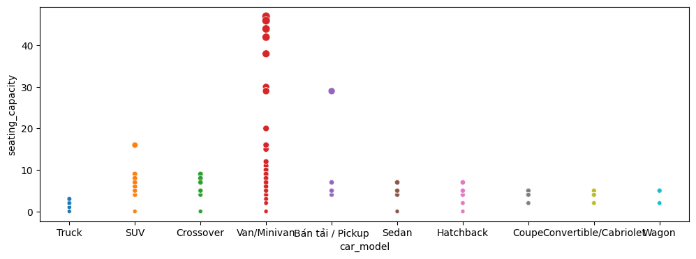

```python
plt.figure(figsize=(12,4))
sns.scatterplot(x='car_model',y='seating_capacity',data=data_3,hue='car_model',legend=False,
                size='seating_capacity')
```

considering zscore

```python
data_3['zscore']=data_3.groupby('extracted_name').seating_capacity.transform(zscore).fillna(0)
```

```python
seating_index=data_3[~(data_3.zscore.between(-1,1)) | (data_3.seating_capacity==0)].index.to_list()
```

```python
seating_table=data_3.groupby('extracted_name').seating_capacity\
.agg(lambda x: x.mode().iloc[0] if not x.mode().empty else None).reset_index()\
.rename(columns={0:'occurences'})
```

```python
seating_table.seating_capacity=\
seating_table.seating_capacity.apply(lambda x : int(x[1]) if type(x)==np.ndarray else x)
```

```python
values_seating=data_3[~(data_3.zscore.between(-1,1)) | (data_3.seating_capacity==0)].\
merge(seating_table,on='extracted_name',how='left').seating_capacity_y.to_list()
```

```python
data_4=data_3.copy()
```

```python
data_4.loc[seating_index,'seating_capacity']=values_seating
```

```python
data_4.loc[data_4[data_4.seating_capacity==0].index.to_list(),'seating_capacity']=7
```

### Filling engine_capacity with ML

#### predicting values

```python
out_data=data_4.copy()
```

```python
#car_data.csv == data_4
```

```python
#out_data=out_data.drop(columns='Unnamed: 0')
```

```python
out_data.shape[0]
```

```
30417
```

```python
def filter_outlier(data):
    filter_data=data.copy()
    filter_data['zscore']=filter_data.groupby(['extracted_name','brand_grade','year_of_manufacture'])\
    ['price_dollars'].transform(zscore)
    filter_data=filter_data[(filter_data.zscore.between(-2.5,2.5)) | (filter_data.zscore.isnull())]
    return(filter_data)
```

```python
out=filter_outlier(out_data)
```

```python
out.shape
```

```
(30027, 30)
```

```python
#out.drop(index=out[~(out.zscore.between(-2.5,2.5))& ~(out.zscore.isnull())].index.to_list(),inplace=True)
```

```python
out.extracted_name
```

```
0         Suzuki Super Carry Truck  MT
1              Toyota Land Cruiser  V6
2                  Toyota Innova G  AT
3               Toyota Corolla Cross G
4                  Toyota Innova G  AT
                     ...
30412                Nissan X trail AT
30413                     Lexus ES 250
30414    Ford Ranger Wildtrack  4x4 AT
30415            Mercedes Benz GLC 200
30416     Audi Q8 55 TFSI S-Line Quatt
Name: extracted_name, Length: 30027, dtype: object
```

```python
out=out.reset_index(drop=True)
```

```python
out.shape[0]-out_data.shape[0]
```

```
-390
```

```python
out.columns
```

```
Index(['ad_id', 'origin', 'condition', 'car_model', 'mileage',
       'exterior_color', 'interior_color', 'num_of_doors', 'seating_capacity',
       'engine', 'transmission', 'drive_type', 'fuel_consumption', 'describe',
       'brand', 'grade', 'year_of_manufacture', 'car_name', 'price',
       'changed_price', 'car_price', 'price_dollars', 'engine_type',
       'engine_capacity', 'fuel_per_100km', 'year_of_manufactue', 'price_log',
       'brand_grade', 'extracted_name', 'zscore'],
      dtype='object')
```

```python
model_data=out[['origin','condition','car_model','mileage','exterior_color',
                'interior_color','num_of_doors','seating_capacity','transmission',
                'drive_type','year_of_manufacture','price_dollars','engine_type','engine_capacity',
                'fuel_per_100km','brand_grade']]
```

```python
model_data=pd.get_dummies(model_data,drop_first=True)
```

```python
#scaler=MinMaxScaler()
```

```python
#model_data[['mileage', 'num_of_doors', 'seating_capacity', 'year_of_manufacture',
 #      'price_dollars', 'engine_capacity', 'fuel_per_100km']]=\
#scaler.fit_transform(model_data.select_dtypes(include=['int64','float64']))
```

```python
X_train=model_data[model_data.engine_capacity.notnull()].drop(columns='engine_capacity')
y_train=model_data[model_data.engine_capacity.notnull()][['engine_capacity']]
```

```python
X_test=model_data[model_data.engine_capacity.isnull()].drop(columns='engine_capacity')
y_test=model_data[model_data.engine_capacity.isnull()][['engine_capacity']]
```

```python
X_train,X_val,y_train,y_val=train_test_split(X_train,y_train,test_size=0.15)
```

```python
forest=RandomForestRegressor(random_state=73)
```

```python
forest.fit(X_train,y_train)
```

```
RandomForestRegressor(random_state=73)
```

```python
forest.score(X_val,y_val)
```

```
0.9401080404008988
```

```python
y_pred=forest.predict(X_val)
```

```python
round(mape(y_val,y_pred),6)
```

```
0.023388
```

```python
pd.DataFrame(y_val.engine_capacity.tolist()-y_pred)[0].value_counts().nlargest(10)
```

```
0
 0.000000e+00    1466
 3.996803e-15      90
-3.996803e-15      83
-1.998401e-15      69
-2.664535e-15      61
 4.884981e-15      41
-1.000000e-02      39
-5.000000e-03      36
 3.108624e-15      33
 2.886580e-15      33
Name: count, dtype: int64
```

```python
capacity_values=forest.predict(X_test).tolist()
```

```python
feature_importance=pd.DataFrame(X_train.columns,forest.feature_importances_).reset_index()\
.rename(columns={'index':'importance',0:'feature'}).nlargest(10,'importance')
```

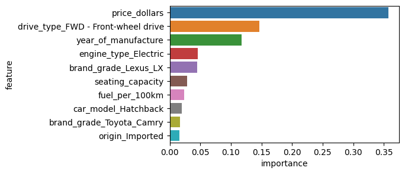

```python
plt.figure(figsize=(5,3))
sns.barplot(x='importance',y='feature',palette=color,data=feature_importance)
```

```python
complete_data=out.copy()
```

#### Cleaning Engine Capacity Values

```python
complete_data.loc[y_test.index.to_list(),'engine_capacity']=capacity_values
```

```python
def filter_engine(data):
    final=pd.DataFrame()
    for keys,df in data.groupby(['brand_grade','year_of_manufacture']):
        df['zscore']=zscore(df.engine_capacity)
        final=pd.concat([final,df],ignore_index=True)
    return(final)
```

```python
ll=filter_engine(complete_data)
```

```python
index_capacity=ll[(ll.zscore.notnull())& ~(ll.zscore.between(-3,3))].index
```

```python
table_capacity=complete_data.groupby('extracted_name').engine_capacity.agg(pd.Series.mode).reset_index()
```

```python
table_capacity.engine_capacity=table_capacity.engine_capacity\
.apply(lambda x : x[1] if type(x)==np.ndarray else x)
```

```python
values_capacity=complete_data.loc[index_capacity]\
.merge(table_capacity,on='extracted_name',how='inner').engine_capacity_y.to_list()
```

```python
complete_data.loc[index_capacity,'engine_capacity']=values_capacity
```

### Feature Engineering

#### Making new features

```python
vie_data=complete_data.copy()
```

```python
#vie_data=pd.read_csv('car_data.csv')
#vie_data.drop(columns='Unnamed: 0',inplace=True)
```

```python
vie_data.shape
```

```
(30027, 30)
```

```python
current_year=datetime.now().year
```

```python
#vie_data.drop(columns='Unnamed: 0',inplace=True)
```

complete_data == final_df.csv

```python
vie_data['brand_grade']=vie_data.brand+'_'+vie_data.grade
```

```python
vie_data['age']=current_year-vie_data.year_of_manufacture
```

#### Kmeans for brand encoding

```python
price_kmeans=KMeans(n_clusters=10)
```

```python
price_kmeans.fit(req_data[['price_dollars']])
```

```
KMeans(n_clusters=10)
```

```python
all_predicted=price_kmeans.predict(req_data[['price_dollars']])
```

```python
reference_table=pd.DataFrame(req_data.price_dollars.values,all_predicted.tolist())
reference_table=reference_table.reset_index().rename(columns={'index':'group_value',0:'price'})
```

```python
px.scatter(data_frame=reference_table,x='group_value',y='price')
```

[interactive chart not shown]

```python
kmean_lookup=reference_table.groupby('group_value').price.min().reset_index()\
.sort_values('price').reset_index(drop=True)
```

```python
kmean_lookup['encoded']=[1,2,3,4,5,6,7,8,9,10]
```

```python
kmean_lookup['price']=kmean_lookup.price.astype('float64')
```

```python
kmean_lookup.loc[0,'price']=0
```

```python
brand_data=vie_data.copy()
```

```python
kf = KFold(n_splits=5, shuffle=True, random_state=42)

for train_index, val_index in kf.split(brand_data):
    train_df, val_df = brand_data.iloc[train_index], brand_data.iloc[val_index]
    model_means = train_df.groupby('brand')['price_dollars'].mean()
    brand_data.loc[val_index, 'Model_Encoded'] = brand_data.loc[val_index, 'brand'].map(model_means)
```

```python
brand_data.head(2)
```

|  | ad_id | origin | condition | car_model | mileage | exterior_color | interior_color | num_of_doors | seating_capacity | engine | ... | engine_type | engine_capacity | fuel_per_100km | year_of_manufactue | price_log | brand_grade | extracted_name | zscore | age | Model_Encoded |
| --- | --- | --- | --- | --- | --- | --- | --- | --- | --- | --- | --- | --- | --- | --- | --- | --- | --- | --- | --- | --- | --- |
| 0 | 17042 | Domestic assembly | New car | Truck | 0 | White | gray | 2 | 2 | Petrol\t1.0 L | ... | Petrol | 1.0 | 9.31 | 2022 | 9.255123 | Suzuki_Super Carry Truck | Suzuki Super Carry Truck MT | -0.301437 | 2.0 | 16368.102389 |
| 1 | 53794 | Imported | New car | SUV | 0 | Black | Black | 5 | 7 | Petrol\t3.4 L | ... | Petrol | 3.4 | 10.00 | 2022 | 12.100779 | Toyota_Land Cruiser | Toyota Land Cruiser V6 | -0.371352 | 2.0 | 34016.482476 |

2 rows × 32 columns

```python
by_brand=brand_data.groupby('brand').Model_Encoded.mean().reset_index().dropna()
```

```python
by_brand=pd.merge_asof(by_brand.sort_values('Model_Encoded'),
              kmean_lookup[['price','encoded']],
              left_on='Model_Encoded',right_on='price')[['brand','encoded']]
```

```python
grade_data=vie_data.copy()
```

```python
grade_data['grade_extracted']=grade_data.T\
.apply(lambda x : re.sub(x.brand,'',x.extracted_name))
```

```python
grade_data['grade_extracted']=grade_data.T.apply(lambda x : re.sub(x.grade,'',x.grade_extracted))
```

```python
grade_data['grade_extracted']=grade_data.grade_extracted.str.strip(' ')
```

```python
vie_data.loc[vie_data.index,'brand_code']=vie_data.loc[vie_data.index,'brand']\
.map(by_brand.groupby('brand').encoded.mean())
```

#### Creating Other as a grade value for each brand

```python
other_grades=vie_data[~(vie_data.grade=='other')].brand.unique()+'_'+'other'
```

```python
brand_grade_other=pd.DataFrame(np.concatenate((vie_data.brand_grade.unique(),other_grades)))
```

```python
brand_grade_other=brand_grade_other.rename(columns={0:'brand_grade'})
```

```python
brand_grade_other.loc[brand_grade_other.shape[0],'brand_grade']='other_other'
```

encoder for all values

```python
encoder_brand_grade=OneHotEncoder(drop='first')
```

```python
encoder_brand_grade.fit(brand_grade_other[['brand_grade']])
```

```
OneHotEncoder(drop='first')
```

#### Selecting important features

```python
model_data=vie_data[['origin','condition','car_model','mileage','exterior_color',
                'interior_color','seating_capacity','transmission',
                'drive_type','price_dollars','engine_type','engine_capacity','age',
                'brand_code','brand_grade']]
```

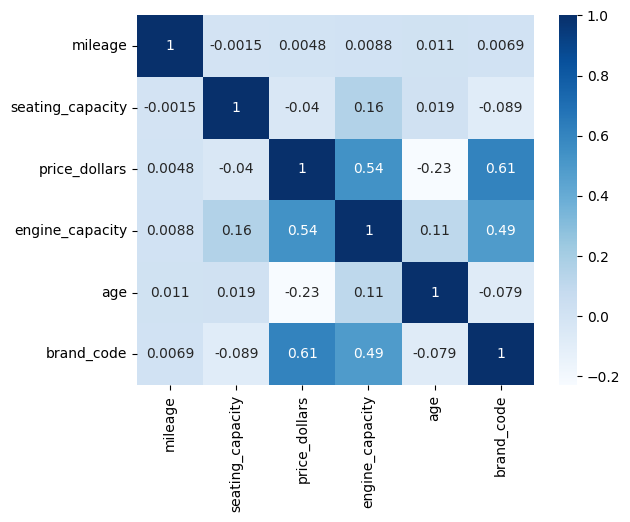

```python
sns.heatmap(model_data.select_dtypes(exclude='object').corr(),annot=True,cmap='Blues')
```

```python
encoder_except_brand_grade=OneHotEncoder(drop='first')
```

```python
brand_grade_encoded=encoder_brand_grade.transform(model_data[['brand_grade']]).toarray()
```

```python
other_data_encoded=\
encoder_except_brand_grade.fit_transform(model_data.drop(columns='brand_grade').\
                                         select_dtypes(include='object')).toarray()
```

```python
scaler=MinMaxScaler()
```

```python
model_data['mileage']=scaler.fit_transform(model_data[['mileage']])
```

```python
price_prediction_data=pd.concat(
    [model_data.select_dtypes(exclude='object'),
     pd.DataFrame(other_data_encoded,columns=encoder_except_brand_grade.get_feature_names_out()),
     pd.DataFrame(brand_grade_encoded,columns=encoder_brand_grade.get_feature_names_out())],axis=1)
```

```python
price_prediction_data.isnull().any().sum()
```

```
0
```

```python
X=price_prediction_data.drop(columns='price_dollars')
y=price_prediction_data[['price_dollars']]
```

```python
X_train,X_test,y_train,y_test=train_test_split(X,y,test_size=0.25)
```

```python
X_val,X_test,y_val,y_test=train_test_split(X_test,y_test,test_size=0.5)
```